# GEOG-533 Lab 9

Yuqing Huang

## Question 1

Use R package **UScensus2010county** to complete the following tasks: (20 pt.)

### Question 1(a)

Plot a map of New York counties using the **plot** function.

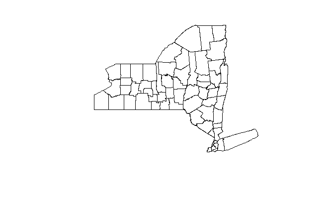

```r
library(UScensus2010county)
data(new_york.county10)
shp <- new_york.county10
plot(shp)
```

### Question 1(b)

Plot a map of New York counties using the **qtm** function.

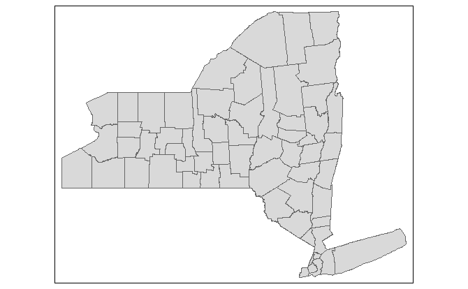

```r
library(tmap)
qtm(shp)
```

### Question 1(c)

How many counties in New York State?

```r
length(shp@polygons)
```

```
[1] 62
```

### Question 1(d)

What’s the 3-digit **fips** code of Broome County?

```r
df <- shp@data
broomef <- df[which(df$NAME10 == 'Broome'), ]$fips
broomef
```

```
[1] "36007"
```

### Question 1(e)

Compute descriptive statistics of the population column (**P0010001**), including total, minimum, maximum, mean, median, and skewness.

```r
library(moments)
sum(df$P0010001)
```

```
[1] 19378102
```

```r
min(df$P0010001)
```

```
[1] 4836
```

```r
max(df$P0010001)
```

```
[1] 2504700
```

```r
mean(df$P0010001)
```

```
[1] 312550
```

```r
median(df$P0010001)
```

```
[1] 91301
```

```r
skewness(df$P0010001)
```

```
[1] 2.579801
```

### Question 1(f)

Create a histogram and a boxplot of the population.

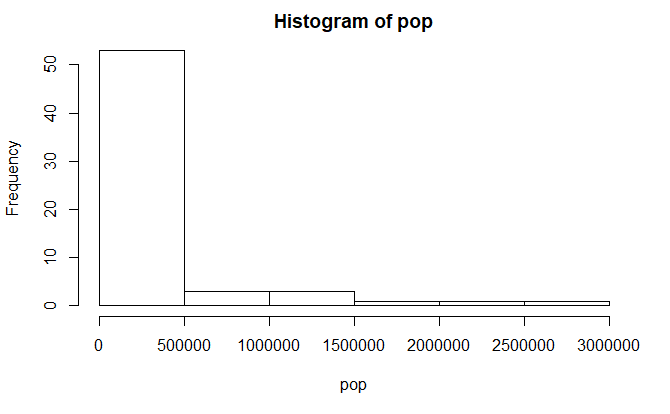

```r
pop <- df$P0010001
hist(pop)
```

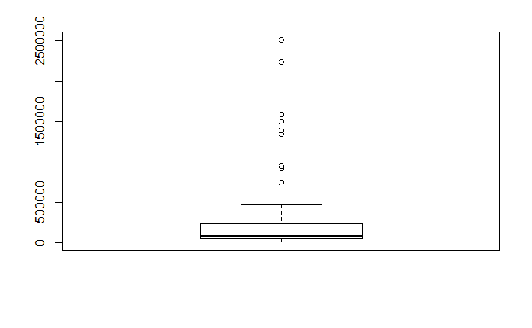

```r
boxplot(pop)
```

## Question 2

Use R package **UScensus2010tract** to complete the following tasks: (20 pt.)

```r
library(UScensus2010tract)
```

### Question 2(a)

Plot a map of New York census tracts using the **plot** function.

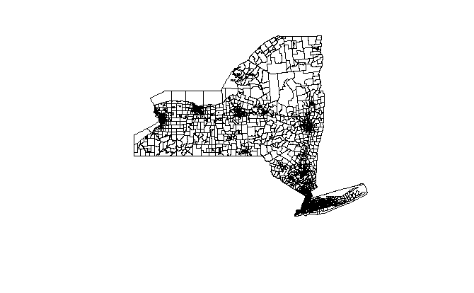

```r
data(new_york.tract10)
shp2 <- new_york.tract10
plot(shp2)
```

### Question 2(b)

Compute the total population based on census tracts.

```r
df2 <- shp2@data
sum(df2$P0010001)
```

```
[1] 19378102
```

### Question 2(c)

Select all census tracts in Broome County and plot the map.

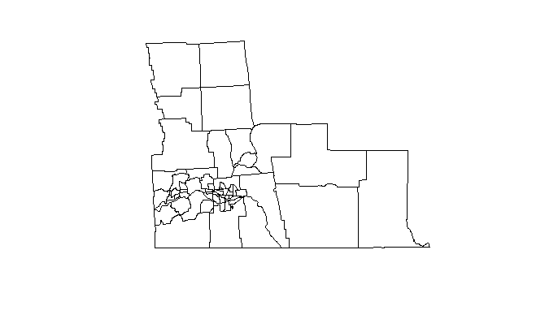

```r
shp22<-shp2[startsWith(as.character(shp2$fips), broomef),]
plot(shp22)
```

### Question 2(d)

What’s the total population of Broome County?

```r
broometr <- df2[startsWith(as.character(df2$fips), broomef),]
total2 <- sum(broometr$P0010001)
total2
```

```
[1] 200600
```

### Question 2(e)

Create a histogram and a boxplot of population based on census tracts of Broome County.

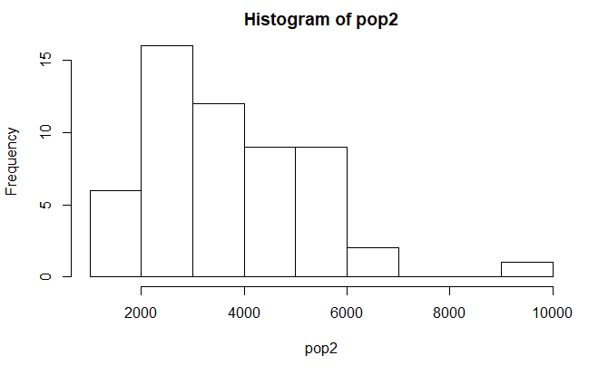

```r
pop2 <- broometr$P0010001
hist(pop2)
```

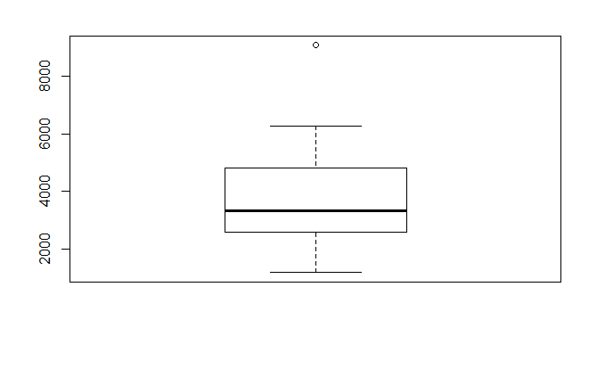

```r
boxplot(pop2)
```

### Question 2(f)

Select the first five columns of the shapefile of Broome County census tract; add a new population ratio column (= census tract population / county population); save the new shapefile to the hard drive.

```r
shp2f <- shp22[,(1:5)]
shp2f$population.ratio <- shp2f$P0010001/total2
df2f <- shp2f@data
df2f
```

|  | state | county | tract | fips | P0010001 | population.ratio |
| --- | --- | --- | --- | --- | --- | --- |
| new_york.tract10_22 | 36 | 007 | 012500 | 36007012500 | 6274 | 0.031276171 |
| new_york.tract10_46 | 36 | 007 | 011902 | 36007011902 | 2732 | 0.013619143 |
| new_york.tract10_47 | 36 | 007 | 000100 | 36007000100 | 3220 | 0.016051844 |
| new_york.tract10_48 | 36 | 007 | 000200 | 36007000200 | 3188 | 0.015892323 |
| new_york.tract10_49 | 36 | 007 | 000300 | 36007000300 | 2975 | 0.014830508 |
| new_york.tract10_50 | 36 | 007 | 000400 | 36007000400 | 2356 | 0.011744766 |
| new_york.tract10_51 | 36 | 007 | 000500 | 36007000500 | 1969 | 0.009815553 |
| new_york.tract10_52 | 36 | 007 | 000600 | 36007000600 | 2296 | 0.011445663 |
| new_york.tract10_53 | 36 | 007 | 000700 | 36007000700 | 3684 | 0.018364905 |
| new_york.tract10_54 | 36 | 007 | 000900 | 36007000900 | 1762 | 0.008783649 |

[output cut: 45 more lines]

## Question 3

Use R packages **raster** and **ncdf4** to complete the following tasks: (20 pt.)

```r
library(raster)
library(ncdf4)
```

### Question 3(a)

Load the multi-band raster dataset “NDVI.nc” into R.

```r
getwd()
```

```
[1] "F:/geog533/GEOG-533/My_labs/CopyOfLab_09"
```

```r
ndvi <- brick("NDVI.nc")
ndvi
```

```
class       : RasterBrick
dimensions  : 360, 720, 259200, 36  (nrow, ncol, ncell, nlayers)
resolution  : 0.5, 0.5  (x, y)
extent      : -180, 180, -90, 90  (xmin, xmax, ymin, ymax)
coord. ref. : +proj=longlat +datum=WGS84 +ellps=WGS84 +towgs84=0,0,0
data source : F:/geog533/GEOG-533/My_labs/CopyOfLab_09/NDVI.nc
names       : X2000.01.01, X2000.02.01, X2000.03.01, X2000.04.01, X2000.05.01, X2000.06.01, X2000.07.01, X2000.08.01, X2000.09.01, X2000.10.01, X2000.11.01, X2000.12.01, X2001.01.01, X2001.02.01, X2001.03.01, ...
Date        : 2000-01-01, 2002-12-01 (min, max)
varname     : NDVI
```

### Question 3(b)

Get the basic information about the dataset, including the number of rows, columns, cells, and bands; spatial resolution, extent, bounding box, and projection.

```r
nrow(ndvi)
```

```
[1] 360
```

```r
ncol(ndvi)
```

```
[1] 720
```

```r
ncell(ndvi)
```

```
[1] 259200
```

```r
nbands(ndvi)
```

```
[1] 36
```

```r
extent(ndvi)
```

```
class       : Extent
xmin        : -180
xmax        : 180
ymin        : -90
ymax        : 90
```

```r
bbox(ndvi)
```

```
    min max
s1 -180 180
s2  -90  90
```

```r
res(ndvi)
```

```
[1] 0.5 0.5
```

```r
projection(ndvi)
```

```
[1] "+proj=longlat +datum=WGS84 +ellps=WGS84 +towgs84=0,0,0"
```

### Question 3(c)

Aggregate all bands to generate a mean NDVI raster and a maximum NDVI raster; save the two new raster datasets to the hard drive.

```r
aggregate(ndvi, fact=2, fun=mean, filename='meanNDVI')
```

```
class       : RasterBrick
dimensions  : 180, 360, 64800, 36  (nrow, ncol, ncell, nlayers)
resolution  : 1, 1  (x, y)
extent      : -180, 180, -90, 90  (xmin, xmax, ymin, ymax)
coord. ref. : +proj=longlat +datum=WGS84 +ellps=WGS84 +towgs84=0,0,0
data source : F:/geog533/GEOG-533/My_labs/CopyOfLab_09/meanNDVI.grd
names       : X2000.01.01, X2000.02.01, X2000.03.01, X2000.04.01, X2000.05.01, X2000.06.01, X2000.07.01, X2000.08.01, X2000.09.01, X2000.10.01, X2000.11.01, X2000.12.01, X2001.01.01, X2001.02.01, X2001.03.01, ...
min values  :           0,           0,           0,           0,           0,           0,           0,           0,           0,           0,           0,           0,           0,           0,           0, ...
max values  :   0.9089250,   0.8816000,   0.8811250,   0.9275750,   0.9325000,   0.9033999,   0.9327000,   0.9038250,   0.8804000,   0.8941250,   0.9066000,   0.9554500,   0.9094500,   0.9066250,   0.8673500, ...
```

```r
aggregate(ndvi, fact=2, fun=max, filename='maxNDVI')
```

```
class       : RasterBrick
dimensions  : 180, 360, 64800, 36  (nrow, ncol, ncell, nlayers)
resolution  : 1, 1  (x, y)
extent      : -180, 180, -90, 90  (xmin, xmax, ymin, ymax)
coord. ref. : +proj=longlat +datum=WGS84 +ellps=WGS84 +towgs84=0,0,0
data source : F:/geog533/GEOG-533/My_labs/CopyOfLab_09/maxNDVI.grd
names       : X2000.01.01, X2000.02.01, X2000.03.01, X2000.04.01, X2000.05.01, X2000.06.01, X2000.07.01, X2000.08.01, X2000.09.01, X2000.10.01, X2000.11.01, X2000.12.01, X2001.01.01, X2001.02.01, X2001.03.01, ...
min values  :           0,           0,           0,           0,           0,           0,           0,           0,           0,           0,           0,           0,           0,           0,           0, ...
max values  :   0.9289000,   0.9383000,   0.9216000,   0.9421000,   0.9439000,   0.9333000,   0.9500000,   0.9268000,   0.9083999,   0.9050999,   0.9463000,   0.9681000,   0.9432999,   0.9267000,   0.8923000, ...
```

### Question 3(d)

Plot the maps of monthly NDVI of the year 2001

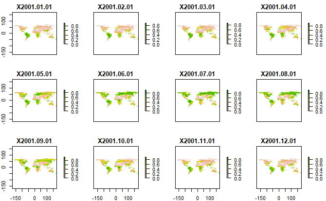

```r
ndvi2001 <- ndvi[[13:24]]
plot(ndvi2001)
```

### Question 3(e)

Create histograms of monthly NDVI of the year 2001.

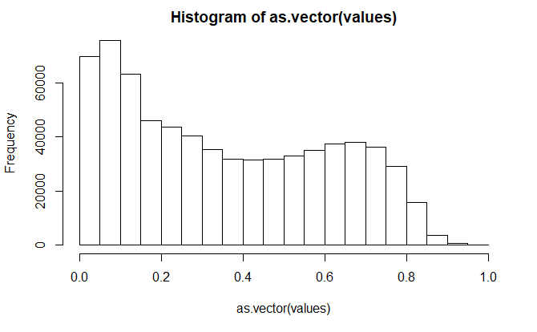

```r
values <- ndvi2001
hist(as.vector(values))
```

### Question 3(f)

Plot the NDVI map of July 2000; click any location with data on the map and retrieve the NDVI time series for all years; plot the NDVI time series of the selected location.

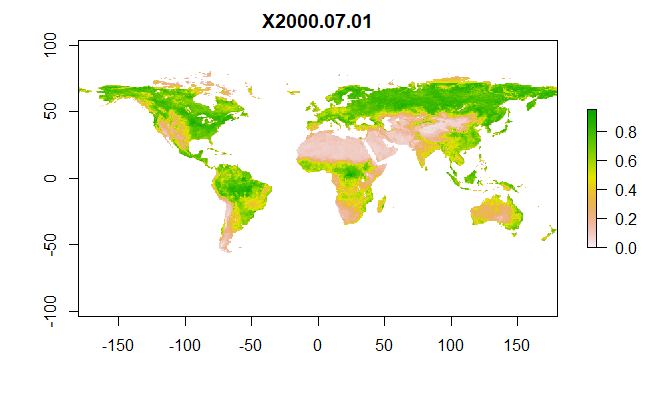

```r
plot(ndvi,7)
```

```r
values <- ndvi[55,55]
values
```

```
     X2000.01.01 X2000.02.01 X2000.03.01 X2000.04.01 X2000.05.01 X2000.06.01
[1,]      0.1129  0.08239999        0.05      0.0501      0.1583      0.5186
     X2000.07.01 X2000.08.01 X2000.09.01 X2000.10.01 X2000.11.01 X2000.12.01
[1,]   0.5969999      0.5731      0.3589      0.1193      0.0791      0.1021
     X2001.01.01 X2001.02.01 X2001.03.01 X2001.04.01 X2001.05.01 X2001.06.01
[1,]      0.0838      0.0432      0.0411      0.0553      0.1739      0.5397
     X2001.07.01 X2001.08.01 X2001.09.01 X2001.10.01 X2001.11.01 X2001.12.01
[1,]      0.4919      0.5962      0.4278       0.129  0.06879999      0.1181
     X2002.01.01 X2002.02.01 X2002.03.01 X2002.04.01 X2002.05.01 X2002.06.01
[1,]  0.07449999      0.0424      0.0347      0.0445      0.3101      0.5692
     X2002.07.01 X2002.08.01 X2002.09.01 X2002.10.01 X2002.11.01 X2002.12.01
[1,]      0.6092      0.6196       0.363      0.1138      0.0891      0.1096
```

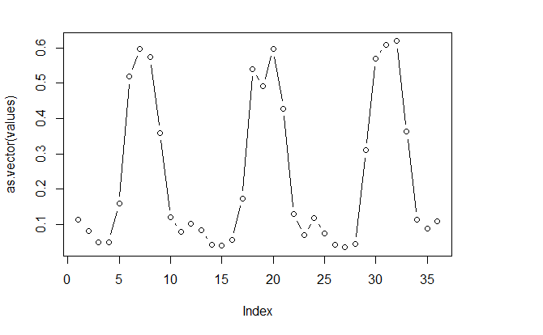

```r
plot(as.vector(values), type="b")
```